# TimeSeries01

doyeon

2021 5 9

```r
library(readxl)
library(tidymodels)
library(caret)
library(lubridate)
library(skimr)
library(fUnitRoots)
library(forecast)
library(gridExtra)
library(lmtest)
library(FitAR)
```

Data Import

```r
raw_data <- read_excel("kospi.xls")
data <- raw_data
data %>% head()
```

```
## # A tibble: 6 x 2
##   일자       현재지수
##   <chr>         <dbl>
## 1 2010/01/04    1696.
## 2 2010/01/05    1691.
## 3 2010/01/06    1705.
## 4 2010/01/07    1683.
## 5 2010/01/08    1695.
## 6 2010/01/11    1694.
```

```r
data %>% skim()
```

Data summary

| Name | Piped data |
| --- | --- |
| Number of rows | 2437 |
| Number of columns | 2 |
| _______________________ |  |
| Column type frequency: |  |
| character | 1 |
| numeric | 1 |
| ________________________ |  |
| Group variables | None |

**Variable type: character**

| skim_variable | n_missing | complete_rate | min | max | empty | n_unique | whitespace |
| --- | --- | --- | --- | --- | --- | --- | --- |
| 일자 | 0 | 1 | 10 | 10 | 0 | 2437 | 0 |

**Variable type: numeric**

| skim_variable | n_missing | complete_rate | mean | sd | p0 | p25 | p50 | p75 | p100 | hist |
| --- | --- | --- | --- | --- | --- | --- | --- | --- | --- | --- |
| 현재지수 | 0 | 1 | 2033.77 | 192.98 | 1552.79 | 1929.25 | 2004.04 | 2099.49 | 2598.19 | ▁▆▇▂▂ |

Pre-processing01

```r
data2 <- data %>%
    mutate(일자 = lubridate::ymd(일자)) %>%
    mutate(년 = lubridate::year(일자),
            월 = month(일자),
            일 = day(일자)) %>%
    group_by(년,월) %>%
    mutate(월평균지수 = sum(현재지수)/n()) %>%
    select(월평균지수) %>%
    distinct()
data2 %>% tail
```

```
## # A tibble: 6 x 3
## # Groups:   년, 월 [6]
##      년    월 월평균지수
##   <dbl> <dbl>      <dbl>
## 1  2019     6      2105.
## 2  2019     7      2079.
## 3  2019     8      1944.
## 4  2019     9      2045.
## 5  2019    10      2066.
## 6  2019    11      2137.
```

ts 변환

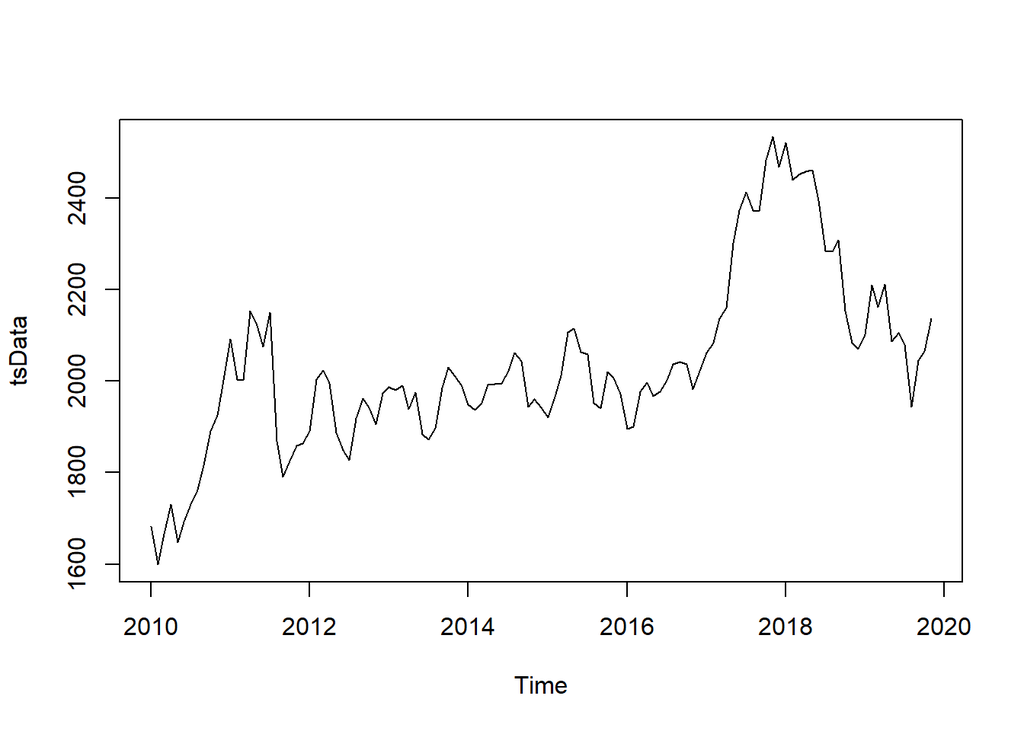

```r
tsData <- ts(data2$월평균지수,frequency = 12,start = c(2010,1),end = c(2019,11))
plot(tsData)
```

1-1) ARIMA 모델

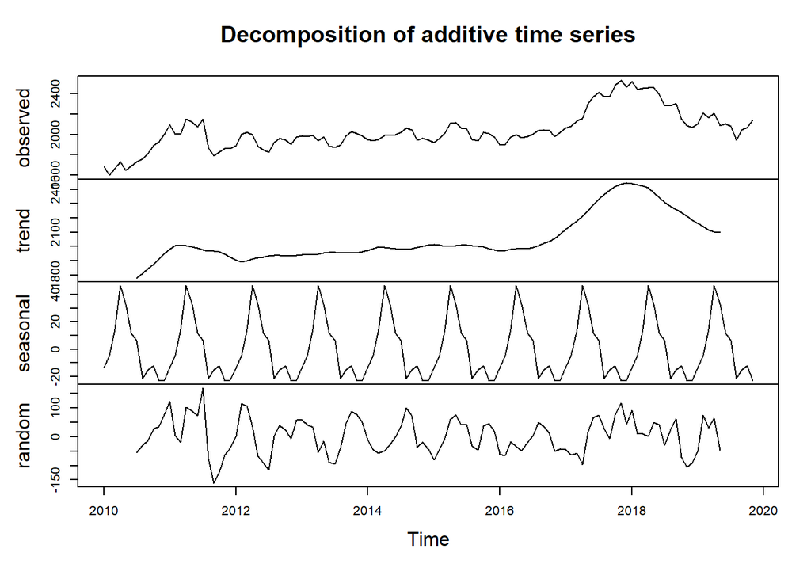

```r
components.ts <- decompose(tsData)
plot(components.ts)
```

-관측값 ( Observed ) – 실제 데이터 플롯  
-추세 ( Trend ) – 데이터 점들의 전반적인 상향 또는 하향 움직임  
-계절성 ( Seasonal ) – 데이터 점들의 월별/년별 패턴  
-임의값 ( Random ) – 데이터의 설명할 수 없는 부분  
*분산이 일정하지 않을 경우 변환을 통해서 해결할 수 있다.

차분 진행 For ARIMA모델

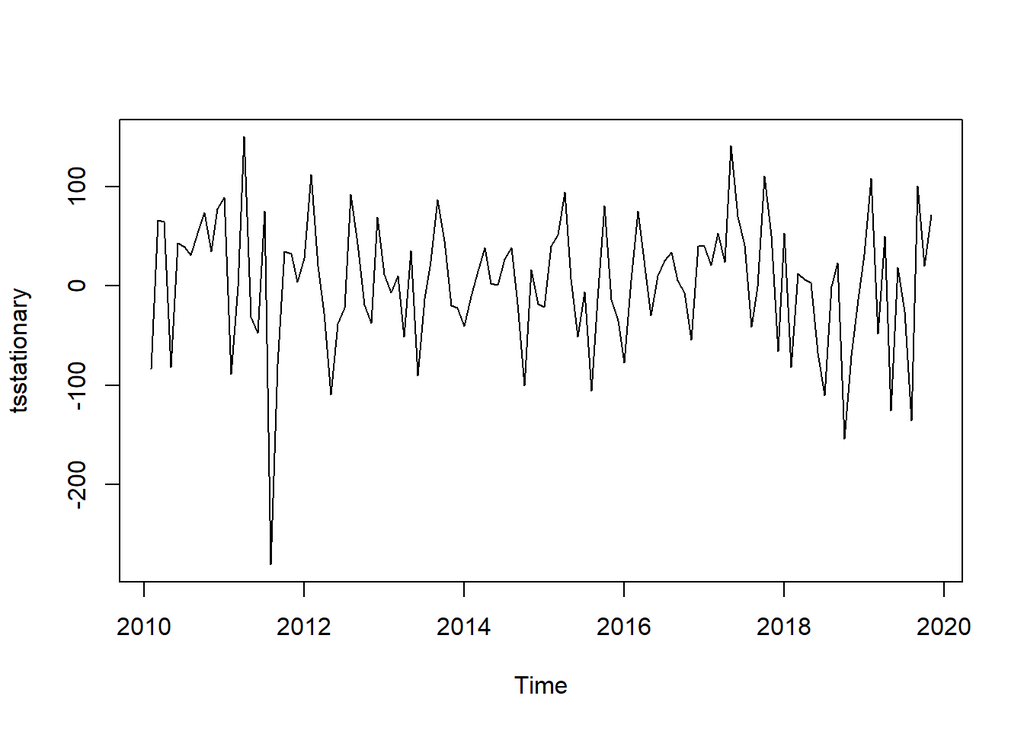

```r
tsstationary <-  diff(tsData, differences=1)
plot(tsstationary)
```

##1차 차분을 통해서 비정상성 해결되었음.

계절성 제거

```r
timeseriesseasonallyadjusted <- tsData- components.ts$seasonal
timeseriesseasonallyadjusted
```

```
##           Jan      Feb      Mar      Apr      May      Jun      Jul      Aug
## 2010 1695.538 1603.664 1650.991 1683.700 1615.137 1680.267 1724.777 1783.471
## 2011 2104.991 2007.577 1988.156 2106.545 2088.709 2062.973 2143.710 1890.695
## 2012 1904.392 2007.939 2008.894 1949.333 1853.188 1836.929 1820.404 1940.199
## 2013 1999.484 1984.563 1975.730 1892.297 1941.291 1872.742 1865.422 1918.249
## 2014 1961.600 1942.441 1937.917 1944.604 1960.972 1983.413 2015.606 2082.220
## 2015 1934.373 1965.709 1998.106 2060.681 2081.736 2052.015 2051.688 1973.836
## 2016 1908.032 1905.318 1961.990 1949.584 1933.512 1965.359 1996.137 2057.943
## 2017 2075.114 2087.503 2121.662 2113.596 2268.727 2360.534 2406.553 2393.471
## 2018 2534.318 2443.812 2437.057 2411.638 2428.137 2382.837 2277.908 2305.084
## 2019 2115.365 2214.907 2147.402 2165.534 2053.735 2093.633 2073.134 1965.525
##           Sep      Oct      Nov      Dec
## 2010 1830.741 1901.796 1947.739 2025.287
## 2011 1805.941 1837.976 1881.827 1886.013
## 2012 1976.280 1954.292 1927.735 1996.624
## 2013 1999.386 2041.774 2032.956 2011.117
## 2014 2057.702 1954.901 1982.679 1964.708
## 2015 1954.574 2032.666 2029.812 1994.311
## 2016 2057.546 2048.131 2004.778 2044.449
## 2017 2386.835 2494.970 2556.542 2490.509
## 2018 2322.317 2165.575 2106.365 2092.912
## 2019 2060.196 2077.846 2160.391
```

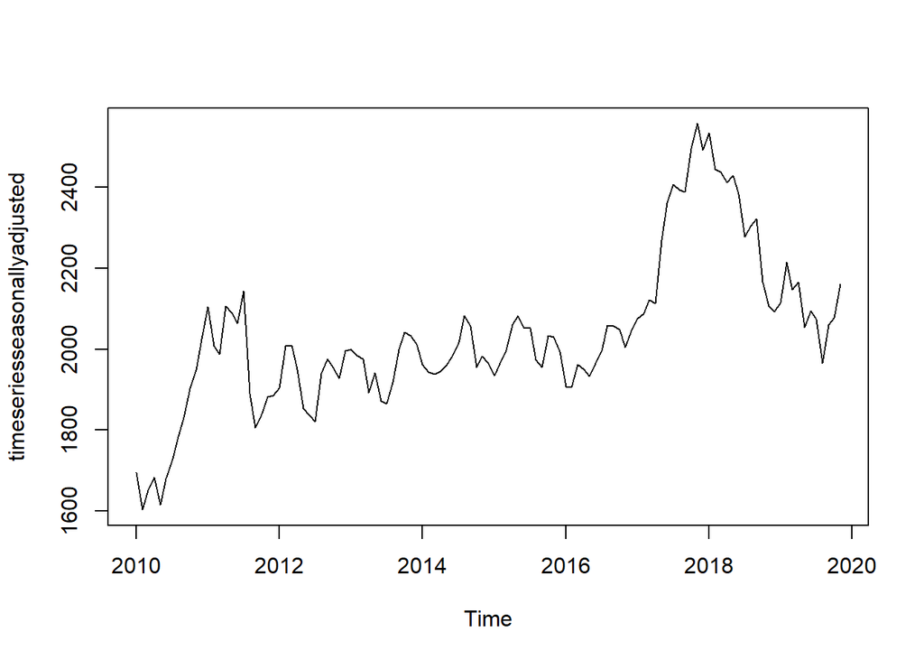

```r
plot(timeseriesseasonallyadjusted) #여전히 비정상성 존재 > 차분 진행
```

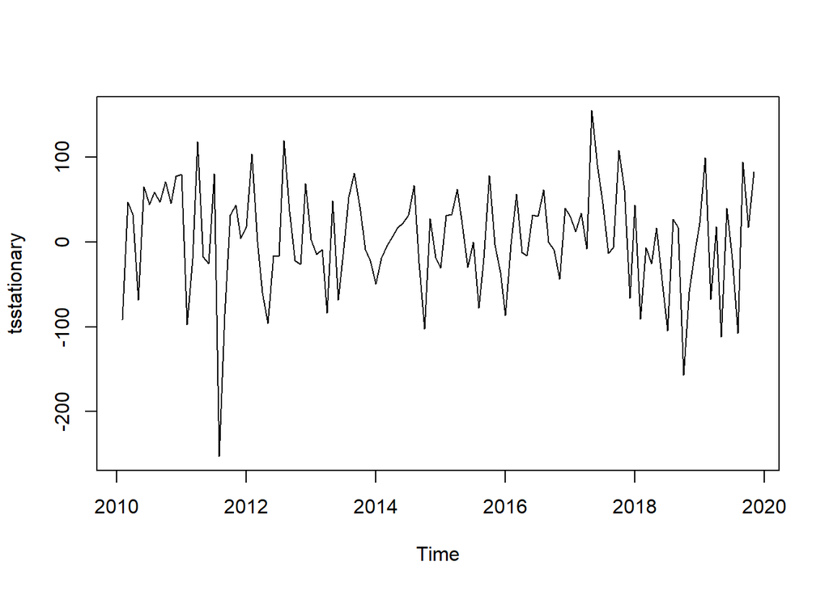

```r
tsstationary <- diff(timeseriesseasonallyadjusted, differences=1)
plot(tsstationary) #비정상성 해결
```

Setup Model

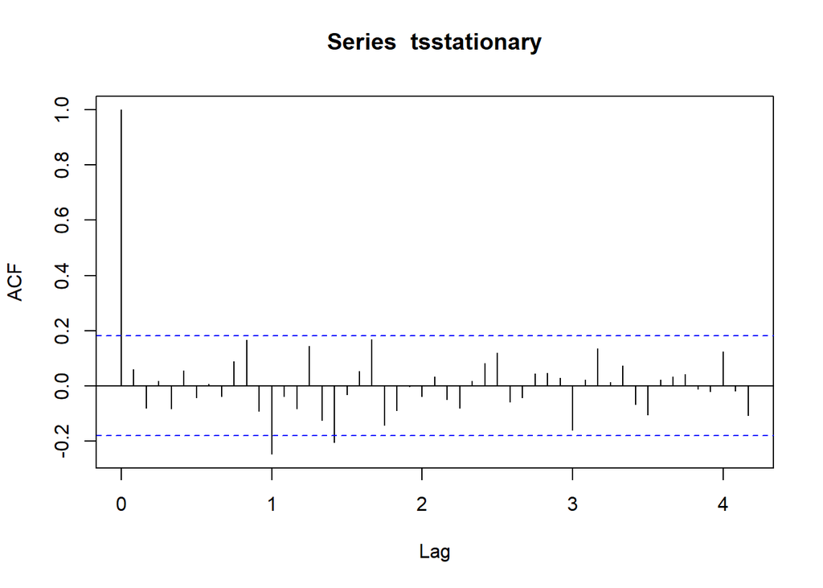

```r
acf(tsstationary,lag.max = 50) #1이후 절단
```

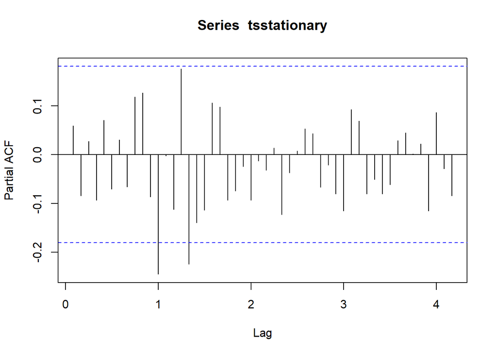

```r
pacf(tsstationary,lag.max = 50) #l이후 절단단
```

acf / pacf 분석에 의한 모델  
AR(1) > ARIMA(1,1,0) MA(1) > ARIMA(0,1,1)  
ARMA(1,1) > ARIMA(1,1,1)

```r
#1
Arima(tsstationary,order = c(1,1,0))
```

```
## Series: tsstationary
## ARIMA(1,1,0)
##
## Coefficients:
##           ar1
##       -0.4199
## s.e.   0.0847
##
## sigma^2 estimated as 5991:  log likelihood=-674.44
## AIC=1352.88   AICc=1352.99   BIC=1358.4
```

```r
#AIC 1352.99
```

```r
#2
Arima(tsstationary,order = c(0,1,1))
```

```
## Series: tsstationary
## ARIMA(0,1,1)
##
## Coefficients:
##           ma1
##       -1.0000
## s.e.   0.0268
##
## sigma^2 estimated as 3926:  log likelihood=-652.01
## AIC=1308.02   AICc=1308.12   BIC=1313.54
```

```r
#Aic 1308.12
```

```r
Arima(tsstationary,order = c(1,1,1))
```

```
## Series: tsstationary
## ARIMA(1,1,1)
##
## Coefficients:
##          ar1      ma1
##       0.0698  -1.0000
## s.e.  0.0939   0.0254
##
## sigma^2 estimated as 3946:  log likelihood=-651.73
## AIC=1309.46   AICc=1309.67   BIC=1317.75
```

```r
#AIC 1309.67
```

데이터 분할을 통한 예측 검정

```r
train <- window(tsstationary,end = c(2017,12))
test <- window(tsstationary,start = c(2018,1))
```

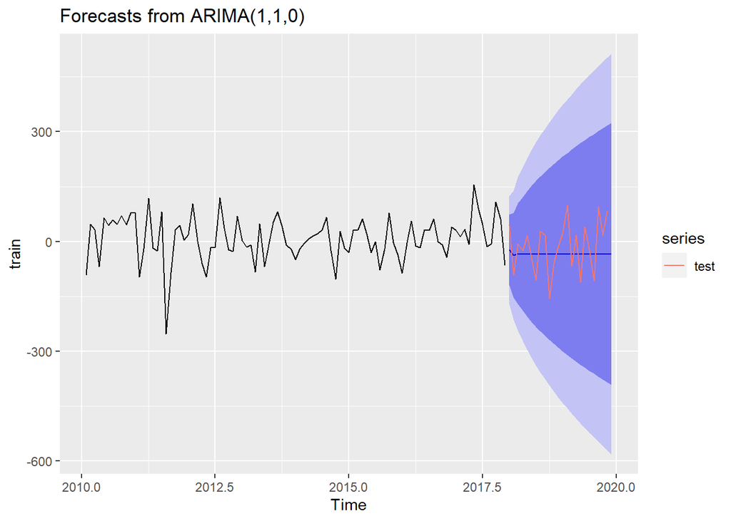

```r
#1
Fit1 <- Arima(train,order = c(1,1,0))
Fit1_fcast <- forecast(Fit1,12*2)
autoplot(Fit1_fcast)+ autolayer(test)
```

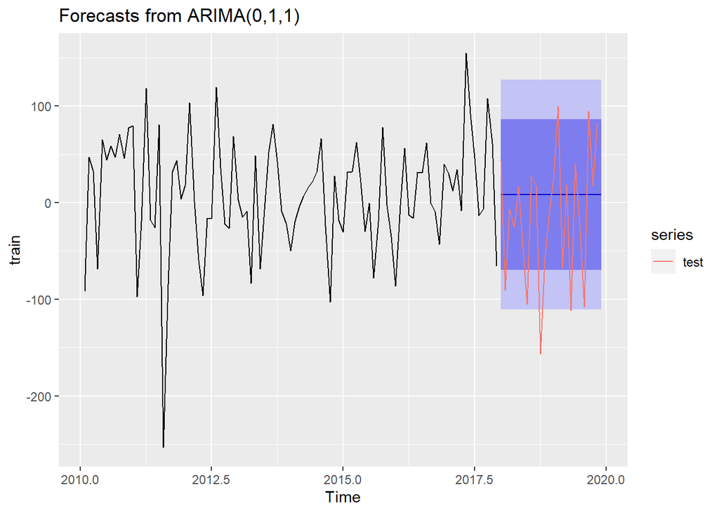

```r
#2
Fit2 <- Arima(train,order = c(0,1,1))
Fit2_fcast <- forecast(Fit2,h = 12*2)
autoplot(Fit2_fcast)+autolayer(test)
```

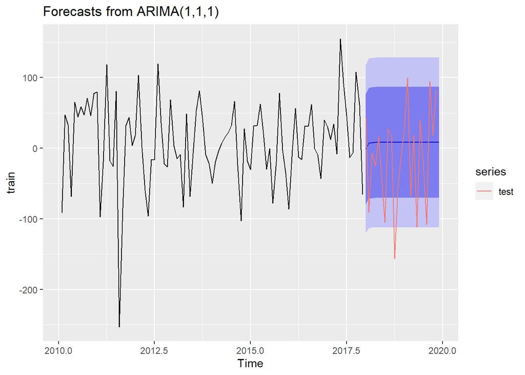

```r
Fit3 <- Arima(train,order = c(1,1,1))
Fit3_fcast <- forecast(Fit3,h = 12*2)
autoplot(Fit3_fcast)+autolayer(test)
```

최종 모델 선정

```r
test1 <- Arima(test,model = Fit1)
accuracy(test1)
```

```
##                    ME     RMSE      MAE     MPE    MAPE      MASE       ACF1
## Training set 1.644819 87.66223 71.15806 60.0479 173.652 0.6854083 -0.3367458
```